# Summary of basic findings

#### First, Set up the environment and load the data

```r
rm(list=ls())
library(tidyverse)  # to use ggplot
currentDir <-  getwd()
setwd(currentDir)
load("step3_gpSummary.Rda")
```

#### Set up some formating for the plots

Set up some good format, apatheme is good for publication, with white background, with black axis lines, no grids Default theme is good for visual comparison (theme_gray() with white grid lines, gray background)

```r
apatheme = theme_bw()+
  theme(panel.grid.major = element_blank(),
        panel.grid.minor = element_blank(),
        panel.border = element_blank(),
        axis.line=element_line())
dodge = position_dodge(width=0.9)
```

## 1a. Plot the 2 block type x 2 trial type CSPC effect: RT

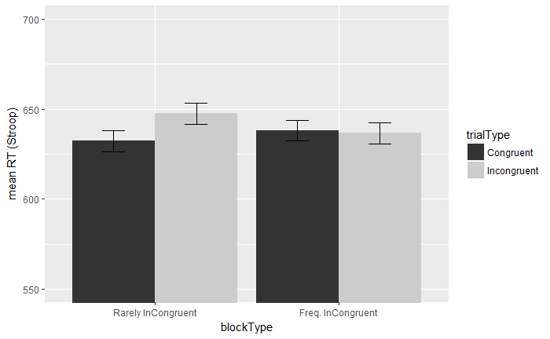

```r
levels(CSPC$trialType) <- c("Congruent", "Incongruent")
levels(CSPC$blockType) <- c("Rarely InCongruent", "Freq. InCongruent")
CSPC %>%
  ggplot(aes(x = blockType, y = gpmeanRT, fill = trialType))  +
  geom_col(position = dodge) +
  geom_errorbar(aes(ymax = gpmeanRT + (1*SE_rt), ymin = gpmeanRT - (1*SE_rt)),
                position = dodge, width = .25) +
  #apatheme +
  ylab("mean RT (Stroop)") +
  coord_cartesian(ylim=c(550,700)) +
  scale_fill_grey()
```

```r
# alternatively, can use geom_bar(stat='identity', position = dodge) in lieu of goem_col(poistion = dodge)
# the default of geom_bar is count, but the default for geom_col is 'identity' (data)
```

## 1b. Plot the 2 half x 2 block type x 2 trial type CSPC effect: RT

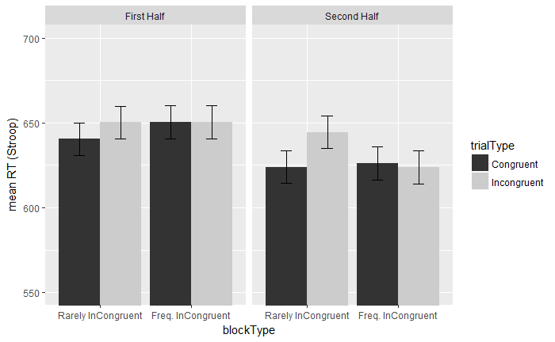

```r
levels(CSPC_half$half) <- c("First Half", "Second Half")
levels(CSPC_half$blockType) <- c("Rarely InCongruent", "Freq. InCongruent")
levels(CSPC_half$trialType) <- c("Congruent", "Incongruent")
CSPC_half %>%
  ggplot(aes(x = blockType, y = gpmeanRT, fill = trialType))  +
  geom_col(position = dodge) +
  geom_errorbar(aes(ymax = gpmeanRT + (1*SE_rt), ymin = gpmeanRT - (1*SE_rt)),
                position = dodge, width = .25) +
  facet_grid(.~half) +
  ylab("mean RT (Stroop)") +
  coord_cartesian(ylim = c(550,700)) +
  scale_fill_grey()
```

## 2.Plot the 2 block type x 2 trial type CSPC effect: ACC

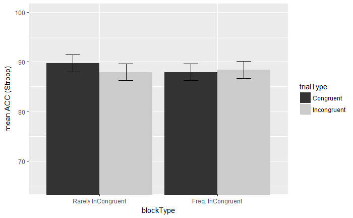

```r
CSPC %>%
  ggplot(aes(x = blockType, y = gpmeanACC, fill = trialType))  +
  geom_col(position = dodge) +
  geom_errorbar(aes(ymax = gpmeanACC + (1*SE_acc), ymin = gpmeanACC - (1*SE_acc)),
                position = dodge, width = .25) +
  ylab("mean ACC (Stroop)") +
  coord_cartesian(ylim=c(65,100)) +
  scale_fill_grey()
```

## 3a.Plot the 2 block type x 2 trial type ISSP effect: RT

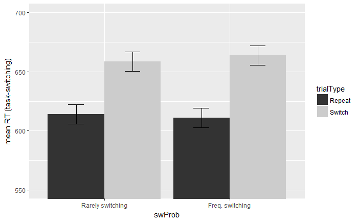

```r
levels(ISSP$trialType) <- c("Repeat", "Switch")
levels(ISSP$swProb) <- c("Rarely switching", "Freq. switching")
ISSP %>%
  ggplot(aes(x = swProb, y = gpmeanRT, fill = trialType))  +
  geom_col(position = dodge) +
  geom_errorbar(aes(ymax = gpmeanRT + (1*SE_rt), ymin = gpmeanRT - (1*SE_rt)),
                position = dodge, width = .25) +
  ylab("mean RT (task-switching)") +
  coord_cartesian(ylim=c(550,700)) +
  scale_fill_grey()
```

## 3b.Plot the 2 half x 2 block type x 2 trial type ISSP effect: RT

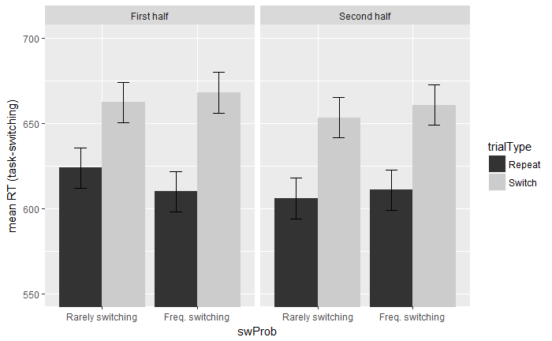

```r
levels(ISSP_half$trialType) <- c("Repeat", "Switch")
levels(ISSP_half$swProb) <- c("Rarely switching", "Freq. switching")
levels(ISSP_half$half) <- c("First half", "Second half")
ISSP_half %>%
  ggplot(aes(x = swProb, y = gpmeanRT, fill = trialType))  +
  geom_col(position = dodge) +
  geom_errorbar(aes(ymax = gpmeanRT + (1*SE_rt), ymin = gpmeanRT - (1*SE_rt)),
                position = dodge, width = .25) +
  facet_grid(.~half) +
  ylab("mean RT (task-switching)") +
  coord_cartesian(ylim=c(550,700)) +
  scale_fill_grey()
```

## 4.Plot the 2 block type x 2 trial type ISSP effect: ACC

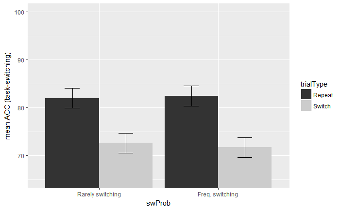

```r
ISSP %>%
  ggplot(aes(x = swProb, y = gpmeanACC, fill = trialType))  +
  geom_col(position = dodge) +
  geom_errorbar(aes(ymax = gpmeanACC + (1*SE_acc), ymin = gpmeanACC - (1*SE_acc)),
                position = dodge, width = .25) +
  ylab("mean ACC (task-switching)") +
  coord_cartesian(ylim=c(65,100)) +
  scale_fill_grey()
```

## 5a.Plot the memory performance as a function of control context previously (2 block type x 2 trial type) in the Stroop task

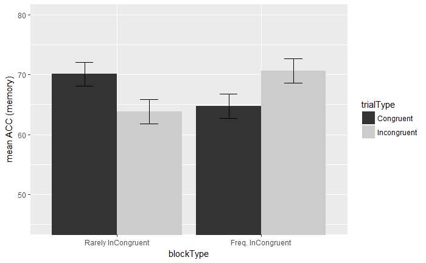

```r
levels(recogM$trialType) <- c("Congruent", "Incongruent","New")
levels(recogM$blockType) <- c("Rarely InCongruent", "Freq. InCongruent", "New")
recogM %>%
  ggplot(aes(x = blockType, y = gpmeanACC, fill = trialType))  +
  geom_col(position = dodge) +
  geom_errorbar(aes(ymax = gpmeanACC + (1*SE_acc), ymin = gpmeanACC - (1*SE_acc)),
                position = dodge, width = .25) +
  ylab("mean ACC (memory)") +
  coord_cartesian(ylim=c(45,80)) +
  scale_fill_grey()
```

## 5b.Plot the memory performance as a function of control context previously (2 half x 2 block type x 2 trial type) in the Stroop task

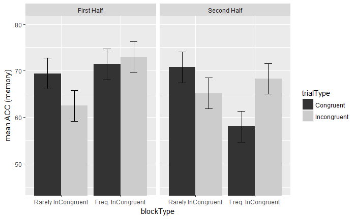

```r
levels(recogM_half$trialType) <- c("Congruent", "Incongruent", "New")
levels(recogM_half$blockType) <- c("Rarely InCongruent", "Freq. InCongruent", "New")
levels(recogM_half$half) <- c("New", "First Half", "Second Half")
recogM_half %>%
  ggplot(aes(x = blockType, y = gpmeanACC, fill = trialType))  +
  geom_col(position = dodge) +
  geom_errorbar(aes(ymax = gpmeanACC + (1*SE_acc), ymin = gpmeanACC - (1*SE_acc)),
                position = dodge, width = .25) +
  facet_grid(.~half) +
  ylab("mean ACC (memory)") +
  coord_cartesian(ylim=c(45,80)) +
  scale_fill_grey()
```

## 6.Plot the RT for memory task as a function of control context previously (2 block type x 2 trial type) in the Stroop task

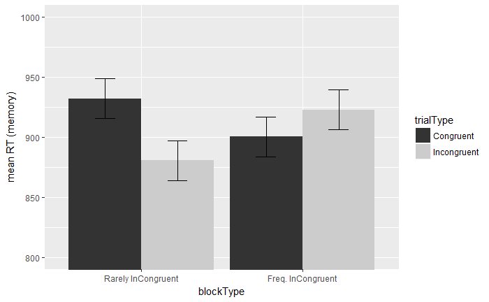

```r
recogM %>%
  ggplot(aes(x = blockType, y = gpmeanRT, fill = trialType))  +
  geom_col(position = dodge) +
  geom_errorbar(aes(ymax = gpmeanRT + (1*SE_rt), ymin = gpmeanRT - (1*SE_rt)),
                position = dodge, width = .25) +
  ylab("mean RT (memory)") +
  coord_cartesian(ylim=c(800,1000)) +
  scale_fill_grey()
```

## 7.Scatter plot (CSPC vs. ISSP) to see if there is any relationship bw two effects:

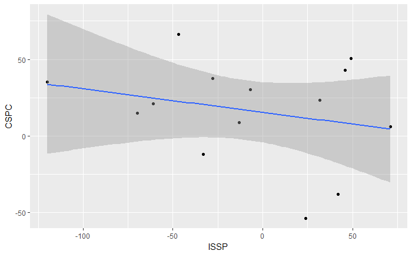

```r
gpBasic %>%
  ggplot(mapping = aes(x = ISSP, y = CSPC)) +
  geom_point() +
  geom_smooth(method=lm)
```

### No correlation so far

```r
pearR <- cor(gpBasic$CSPC, gpBasic$ISSP)
pearR
```

```
[1] -0.2539264
```